# Manipulação de Imagens

Artur Almeida, Brenda Assis, Eraldo Jair e Rafael Yui

24 de agosto de 2022

# KERAS

Keras é uma biblioteca aberta de Deep Learning implementada utilizando a base do TensorFlow para diversas linguagens/plataformas, como Python e R, como foco na sua facilidade para utilização. Ela permite modelar e treinar modelos de redes neurais com poucas linhas de código.

Nesse exemplo, vamos utilizar o Keras para criar um modelo capaz de classificar imagens em carros ou aviões.

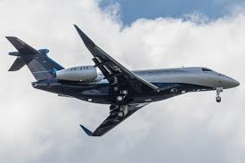

[figure not shown]

# 1 - Carregando os dados

```r
car_dir <- "carros/"
planes_dir <- "avioes/"
verifica_dir <- "verifica/"
```

# 1 - Carregando os dados

```r
car_dir <- "carros/"
planes_dir <- "avioes/"
verifica_dir <- "verifica/"


width <- 30
height <- 30

extrair_caracteristicas <- function (dir_path, width, height){

  img.size <- width * height
  image_name <- list.files(dir_path)
  print(paste("Iniciando Processo", length(image_name), "imagens"))

  lista_parametros <- pblapply(image_name, function(imgname){
    img <- readImage(file.path(dir_path, imgname))
    img_resized <- resize(img, w = width, h = height)
    img_matrix <- as.matrix(img_resized@.Data)
    img_vector <- as.vector(t(img_matrix))

    return(img_vector)
  })

  feature_matrix <- do.call(rbind, lista_parametros)
  feature_matrix <- as.data.frame(feature_matrix)

  names(feature_matrix) <- paste0("pixel", c(1:img.size))
  return(feature_matrix)
}
```

# 1 - Carregando os dados

```r
car_data <- extrair_caracteristicas(dir_path = car_dir, width = width,
                                    height = height)
```

```
## [1] "Iniciando Processo 40 imagens"
```

```r
planes_data <- extrair_caracteristicas(dir_path = planes_dir,
                                       width = width, height = height)
```

```
## [1] "Iniciando Processo 40 imagens"
```

```r
car_data$label <- 0
planes_data$label <- 1
allData <-rbind(car_data,planes_data)   # juntar os dados
```

# 2 - Criar o modelo utilizando Keras

- Modelos Keras são definidos como uma sequência de camadas.
- Esse projeto teste utiliza poucas camadas, as quais as primeiras utilizam a função de ativação ReLU e a função Softmax na última.

-Podemos especificar o número de neurônios no primeiro argumento, e a função de ativação com o parâmetro activation

# 2 - Criar o modelo utilizando Keras

```r
indices <- createDataPartition(allData$label, p=0.9 , list = FALSE)  #caret# criação dos indices para treinamento dos dados - 90%
train <- allData[indices,] # treino
test <- allData[-indices,] # teste

trainLabels <- to_categorical(train$label)
```

```
## Loaded Tensorflow version 2.9.1
```

```r
testLabels <- to_categorical(test$label)

testLabels
```

```
##      [,1] [,2]
## [1,]    1    0
## [2,]    1    0
## [3,]    1    0
## [4,]    1    0
## [5,]    0    1
## [6,]    0    1
## [7,]    0    1
## [8,]    0    1
```

```r
xtrain <- data.matrix(train[,-ncol(train)])
ytrain <- data.matrix(train[,ncol(train)])

xtest <- data.matrix(test[,-ncol(test)])
ytest <- data.matrix(test[,ncol(test)])
```

# 3 - Compilando o modelo

Após modelo definido, é necessário compilá-lo. A compilação ocorre utilizando a biblioteca TensorFlow

Ao compilar, precisamos especificar algumas propriedades, como a função de perda, otimizador e a métrica que será utilizada para avaliar o modelo. Neste projeto, utilizamos a função de perda de Entropia Cruzada Binária, o otimizador Adam (que utiliza o gradiente descendente) e acurácia como métrica.

```r
#####TREINAR MODELO (KERAS)
model <- keras_model_sequential()
model %>%
  layer_dense(units = 256, activation = 'relu', input_shape = c(2700)) %>%  ##1A layer
  layer_dense(units = 128, activation = 'relu')%>%
  layer_dense(units = 64, activation = 'relu')%>%
  layer_dense(units = 32, activation = 'relu')%>%
  layer_dense(units = 2, activation = 'softmax')

summary(model)
```

```
## Model: "sequential"
## ________________________________________________________________________________
##  Layer (type)                       Output Shape                    Param #
## ================================================================================
##  dense_4 (Dense)                    (None, 256)                     691456
##  dense_3 (Dense)                    (None, 128)                     32896
##  dense_2 (Dense)                    (None, 64)                      8256
##  dense_1 (Dense)                    (None, 32)                      2080
##  dense (Dense)                      (None, 2)                       66
## ================================================================================
## Total params: 734,754
## Trainable params: 734,754
## Non-trainable params: 0
## ________________________________________________________________________________
```

```r
model%>%
  compile(loss='binary_crossentropy',
          optimizer = optimizer_adam(),
          metrics = c('accuracy')
          )
```

# 4 - Treinando o modelo

Como nosso modelo definido e compilado, precisamos treiná-lo, ou seja, executar o modelo utilizando nossos dados.

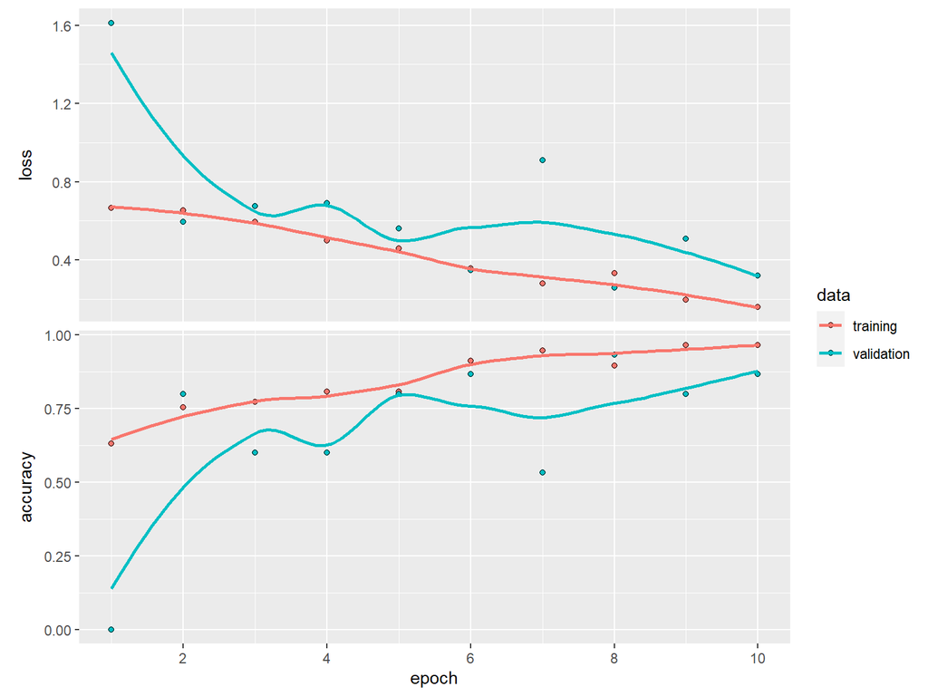

```r
history <- model %>%
  fit(xtrain,
      trainLabels,
      epochs = 10,
      batch_size = 32,
      validation_split = 0.2)

plot(history)
```

# 5 - Avaliando o modelo

Agora que estamos com nosso modelo treinado, precisamos avaliá-lo. Essa avaliação vai dizer o quão bem o modelo foi construído utilizando o conjunto de dados de treinamento.

Pode-se separar os dados entre dados de treinamento e de teste para avaliar o desempenho do modelo com novos dado.

```r
model %>% evaluate(xtest, testLabels, verbose = 1)
```

```
##      loss  accuracy
## 0.2616319 0.8750000
```

```r
pred <- model %>% predict(xtest)  %>% k_argmax()
table(Predicted = as.numeric(pred), Reais = ytest)
```

```
##          Reais
## Predicted 0 1
##         0 4 1
##         1 0 3
```

```r
verifica<-extrair_caracteristicas(verifica_dir, width = width, height = height)
```

```
## [1] "Iniciando Processo 4 imagens"
```

```r
pred_test <- model %>% predict(as.matrix(verifica)) %>% k_argmax()
pred_test
```

```
## tf.Tensor([1 0 0 1], shape=(4), dtype=int64)
```